# freelance

mohie eldin

October, 2019

## Part 1: Data

#### The dataset information is about the orders that have been made from September 2018 to October 2019.

#### It contains originally 64000 observations and 73 columns.

#### I removed 15 column weather because most of them are missing or 99% corelated with another variable.

### causality :

The data is an `observational` and hence we can not conclude causality from it so we will be able to show `association` between variables and experimental data is needed for further causal analysis.

### Data entry problems :

```
##  [1] "cairo"                       "Cairo"
##  [3] "Cairo- helwan"               "Cairo, heliopolis."
##  [5] "Cairo- alex desert road"     "cairpo"
##  [7] "Cairo, Maadi"                "Cairo egypt"
##  [9] "Cairo - Heliopolis"          "Cairo, obour city"
## [11] "CAIRO"                       "Cairo - Fifth Settlement"
## [13] "Cairp"                       "Cairo Alex dessert road"
## [15] "Caito"                       "Cairo-elmaadi-elmearaj city"
## [17] "Cairo 1st settlement"        "CAiro"
## [19] "Cairo, Masaken Sheraton"     "Cairo, Egypt"
```

#### There is no unified way in entering the city data and some other columns !

```
## # A tibble: 7 x 3
##   Name    `Financial Status` Currency
##   <chr>   <chr>              <chr>
## 1 PS49269 pending            EGP
## 2 PS49269 <NA>               <NA>
## 3 PS49269 <NA>               <NA>
## 4 PS49269 <NA>               <NA>
## 5 PS49269 <NA>               <NA>
## 6 PS49269 <NA>               <NA>
## 7 PS49269 <NA>               <NA>
```

#### Most of the customer data is written once and the rest of rows are empty !

### So we have to make in the futur a unified way to enter the data through data validation techniques in Excel.

## Part 2: Research questions

#### 1) What is the best item category and what is the worst ?

#### 2) What is the best 5 items and the worst 5 ?

#### 3) Are we able to categorized the customers into A,B and C classes so that we make customized offers to each ?

#### 4) Do the data reveal some common association between best sellers or between worst sellers or we need more information ?

#### 5) What is the retention rate ?

### Why these are interesting questions ?

#### Mainly answering these questions will make a deeper understanding to customers and open the doors for a better products and better customer satisfaction.

## Part 3: Exploratory data analysis

### Q1) What is the best item category and what is the worst ?

```
## We have  685 different products with 5 categories
```

```
##   Items_category Quantity   Sales Quantity_propotion Sales_propotion
## 1       Backpack    14567 6357979               0.31            0.33
## 2    Summer bags    16391 6130554               0.35            0.32
## 3    Laptop bags    12044 6055048               0.26            0.31
## 4       Slippers     1710  589855               0.04            0.03
## 5   Card holders     2125  323155               0.05            0.02
```

```
##   Items_category Quantity   Sales Quantity_propotion Sales_propotion
## 1    Summer bags    16391 6130554               0.35            0.32
## 2       Backpack    14567 6357979               0.31            0.33
## 3    Laptop bags    12044 6055048               0.26            0.31
## 4   Card holders     2125  323155               0.05            0.02
## 5       Slippers     1710  589855               0.04            0.03
```

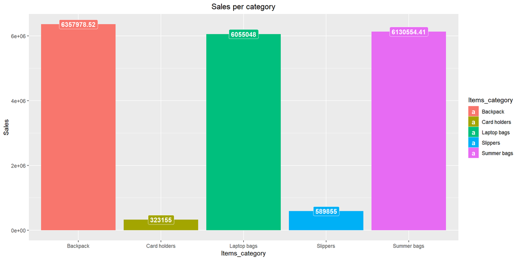

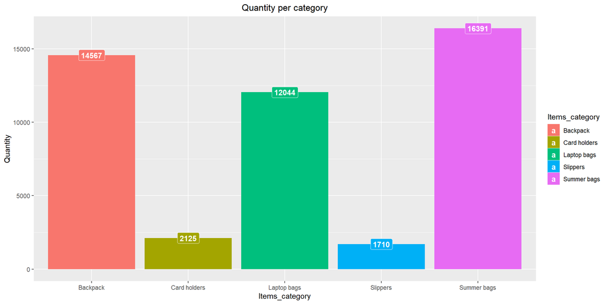

#### We noteced that summer bags soled more than backback; however, their sales are less than backback ! why ?

#### Also the card holders and slipper are not doing so well in both sales and quantity soled which need more investigation on the reasons behind this.

### Q2) What is the best 5 items and the worst 5 ?

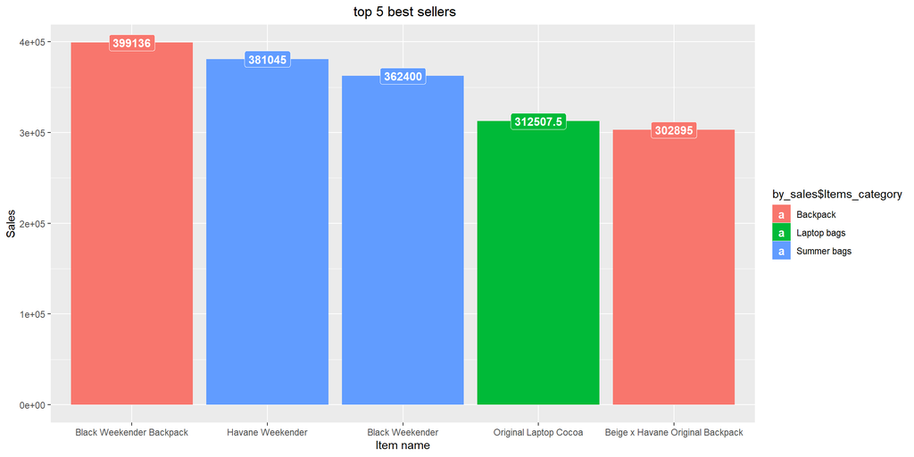

[figure not shown]

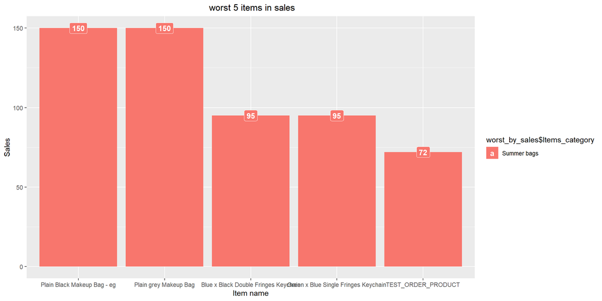

#### Interestingly the worst five items in sales are not slippers or card holders as expected but the five are summer bags !

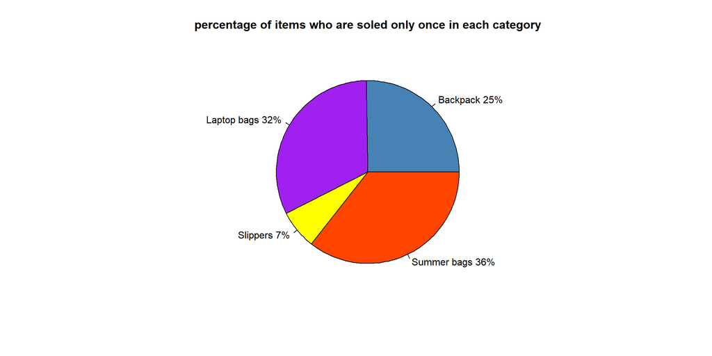

#### Although summer bags are in the best sellers and most demanded items but it also in the worst !

#### Actually we can turn this into a good thing, what about comparing the two groups in terms of the designs, marketing companies, time period and prices !

### Q3) Are we able to categorized the customers into A,B and C classes so that we make customized offers to each ?

```
##
## [    72,   500) [   500,  1000) [  1000,359667]
##           10818            9261            5093
```

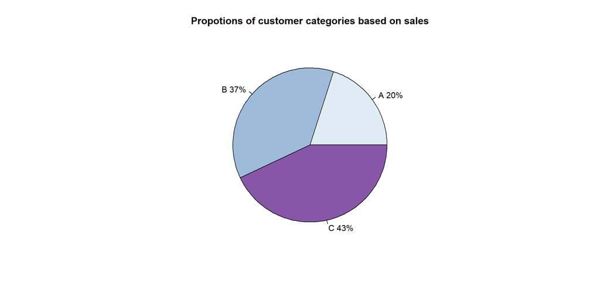

```
##
##         1         2 [  3,666]
##     15472      5567      4133
```

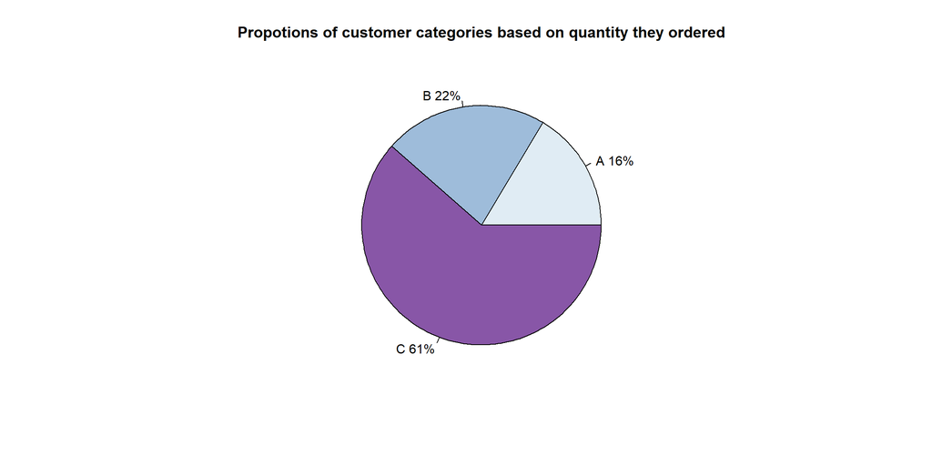

```r
customer_categories %>% filter(Email == "alia.samir@msa.edu.eg") %>% as.data.frame()
```

```
##                   Email sales quantity sales_category quantity_category
## 1 alia.samir@msa.edu.eg   910        8              B                 A
##   SQ_category
## 1         B A
```

#### Now we have a data frame that contains every thing that we need to know about each class, here is some information about calss A for example.

```
## # A tibble: 6 x 3
## # Groups:   Lineitem name [6]
##   `Lineitem name`                    Items_category quantity_soled
##   <chr>                              <chr>                   <dbl>
## 1 13' Beige EtamineLaptop Sleeve     Laptop bags                 6
## 2 13' Black Etamine Laptop Sleeve    Laptop bags                86
## 3 13' Black Laptop Sleeve            Laptop bags                72
## 4 13' Black x OrangeGreen Laptop Bag Laptop bags                15
## 5 13' Black x RedBlue Laptop Bag     Laptop bags                24
## 6 13' Cafe Etamine Laptop Sleeve     Laptop bags                 1
```

#### So now we have a deeper insights about what each class had ordered most and we can use this for customized offers !

### Q4) Do the data reveal some common association between best sellers or between worst sellers or we need more information ?

```
## # A tibble: 166 x 4
## # Groups:   Lineitem name [166]
##    `Lineitem name`                Items_category quantity   sales
##    <chr>                          <chr>             <dbl>   <dbl>
##  1 15' Cafe x Pink Laptop Bag     Laptop bags          40 -22680
##  2 Havane Weekender               Summer bags          35 -21190
##  3 Havane Tassel Backpack         Backpack             40 -18470
##  4 Black Weekender                Summer bags          30 -18045
##  5 15' Black x RedBlue Laptop Bag Laptop bags          27 -15235
##  6 Havane Org Laptop Bag          Laptop bags          25 -13915
##  7 Off White Weekender            Summer bags          22 -13470
##  8 Black Tassel Backpack          Backpack             28 -13102.
##  9 Original Laptop Cocoa          Laptop bags          25 -13052.
## 10 15' Havane x Pink Laptop Bag   Laptop bags          22 -12340
## # ... with 156 more rows
```

```
## # A tibble: 1 x 3
##   `Lineitem name`             sales quantity
##   <chr>                       <dbl>    <dbl>
## 1 15' Cafe x Pink Laptop Bag 261270      453
```

#### So whta about a column that states the reasons of refund ? we can then work on deacresing this rate.

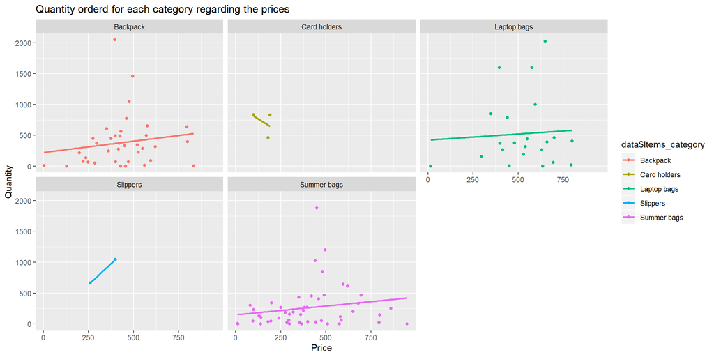

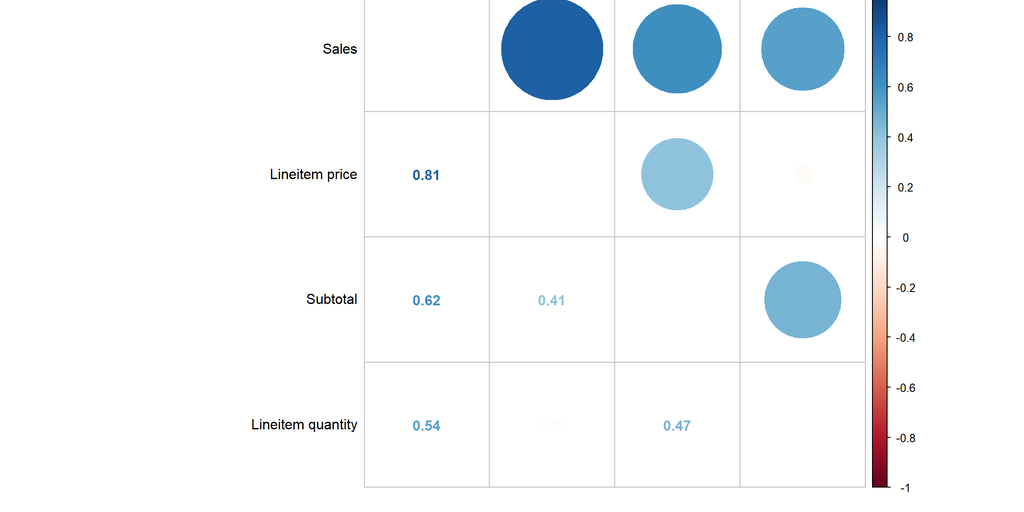

#### Numerical variables are not helping a lot as expected as the date column is the most important one for a time serise analysis.

#### we may need to collect more data that can help us estimate items success of filure such as survies, design categories and more.

### Q5) What is the retention rate ?

#### What is the number of customers in 19 and 18 ?

```
## we had 15832 customers in 2018
```

```
## Now there are  25289 customers in 2019
```

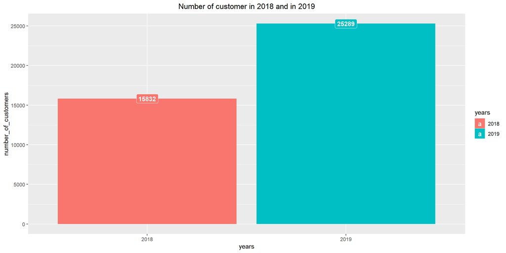

#### This is a huge improvment for increasing the number of customers.

#### So out of the 25,000 that we have now how many ordered more than once ?

```
## There are  6507 bought more than once which is only 26 % of the customers and we need to know why the rest  74 % didn't order again !
```

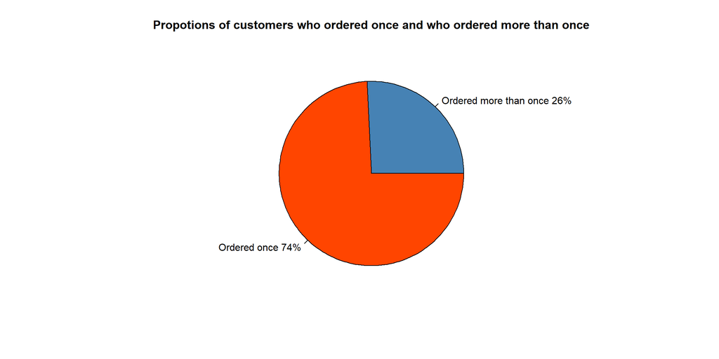

#### We can call them, take a feedback and hopefully to make them order again.

## Part 4 : What’s next ?

#### In the future :

#### 1) The data problems has to be handled.

#### 2) More information need to be collected.

#### 3) This will open the door for a better understanding to customers and items and hence machine learning model will be bulit to predict the customer behaviour which is very interesting and promising !